# task

Karolina

2016 m rugsėjis 16 d

## Plotting World and Country maps in R

Before we begin, we are going to need a few packages. Try to load the following libraries: library(maps) library(mapdata)

If these packages loaded correctly, you can move to the world map section.

If one of the packages gives you an error message and fails to load you will need to install the missing package(s) using the commands

install.packages(“maps”) install.packages(“mapdata”)

The mapdata package contains a highly detailed set of polygons that map out all the countries of the World. It contains around 2 million polygons and is based on data from the CIA World Data Bank II.

To plot a map, we intuitively use the map() function and call the worldHires data:

map(‘worldHires’)

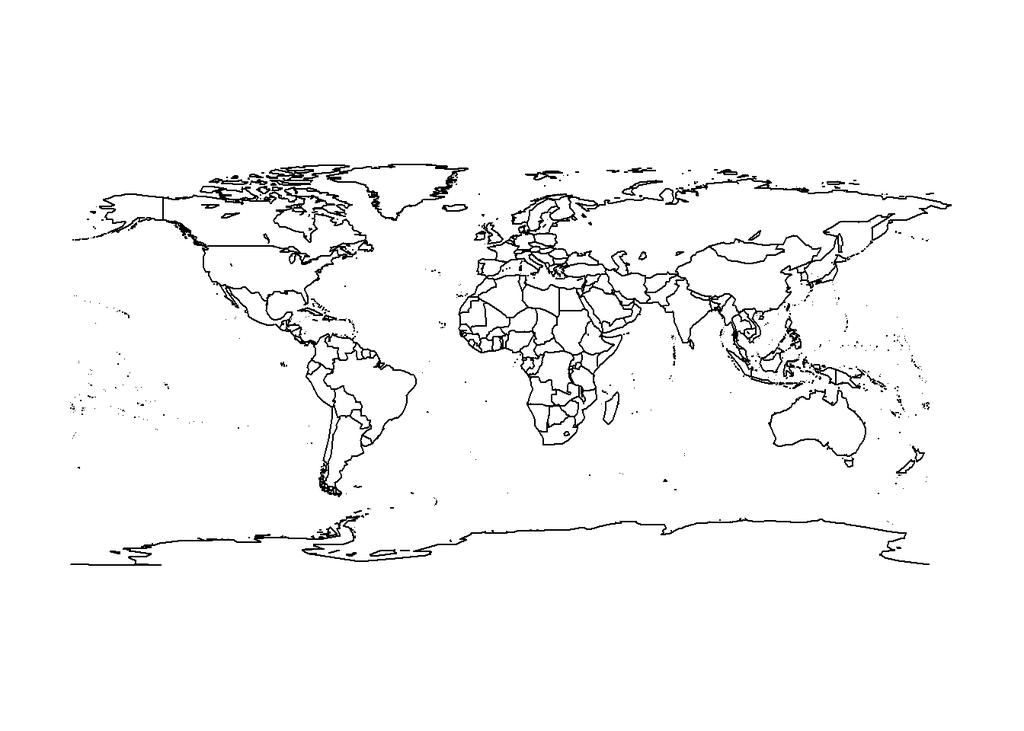

NOTE: This may take a moment to plot due to the high detail of the dataset bring plotted

The command above gives you a plot of the World centered around the GMT timezone. If you would prefer a map centered around the International Date line then use

map(‘world2Hires’)

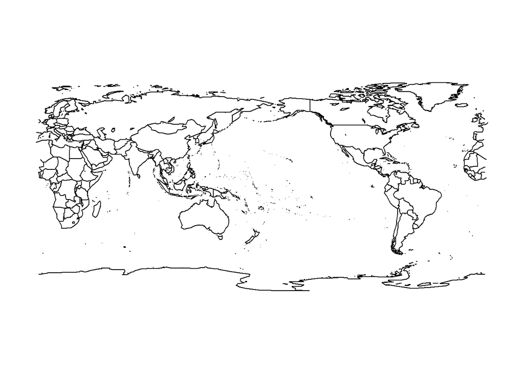

## Plotting Countries

We can select an individual country to plot, such as Italy, by listing the countries we want to plot after the “worldHires” data we are using:

map(‘worldHires’,‘Italy’)

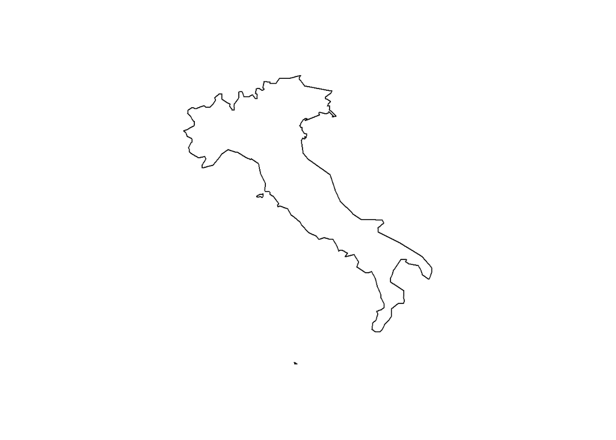

It’s worth noting that countries that you list are not case-sensitive. The software will also try to match and plot all countries that start with whatever you type. For example, if you typed

map(‘worldHires’,‘ch’)

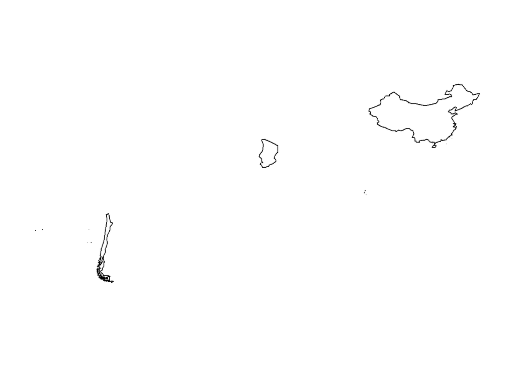

then you will end up with a plot of Chile, China, and any other countries that begin with the letters Ch… Entering ’’ as the country you want to plot will simply plot every country.

## Plotting the UK/British Isles

Firstly, to plot multiple countries, simply list the countries in a vector.

map(‘worldHires’, c(‘UK’, ‘Ireland’, ‘Isle of Man’,‘Isle of Wight’, ‘Wales:Anglesey’))

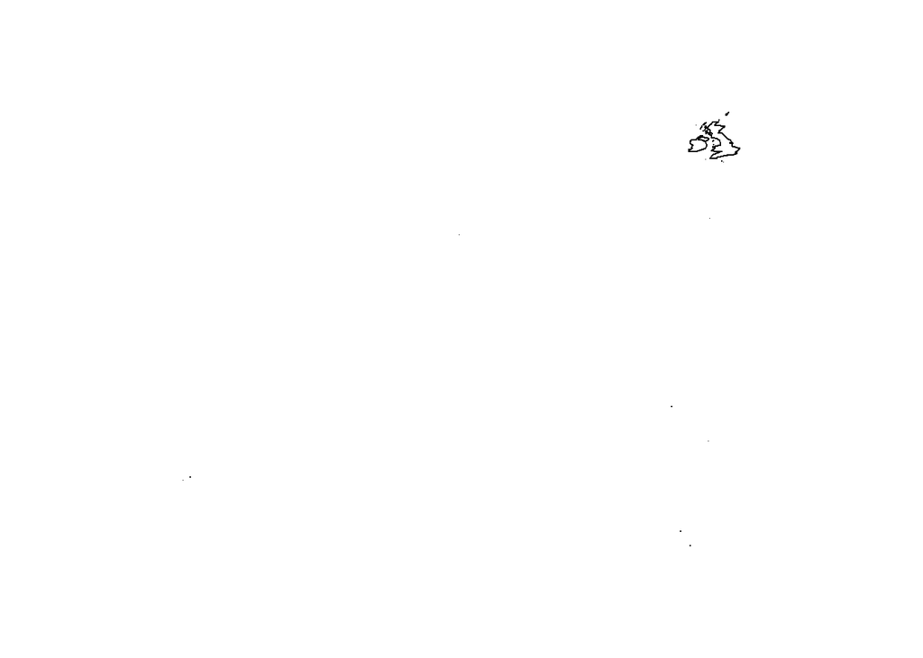

You’ll notice that it looks very small - This is the second problem I wanted to address. It’s actually plotting islands all around the world the belonging to the UK. They are just relatively small so you can’t see them.

To focus on just the British Isles we can limit the plot area by setting the longitudes and lattitudes to plot within:

map(‘worldHires’, c(‘UK’, ‘Ireland’, ‘Isle of Man’,‘Isle of Wight’), xlim=c(-11,3), ylim=c(49,60.9))

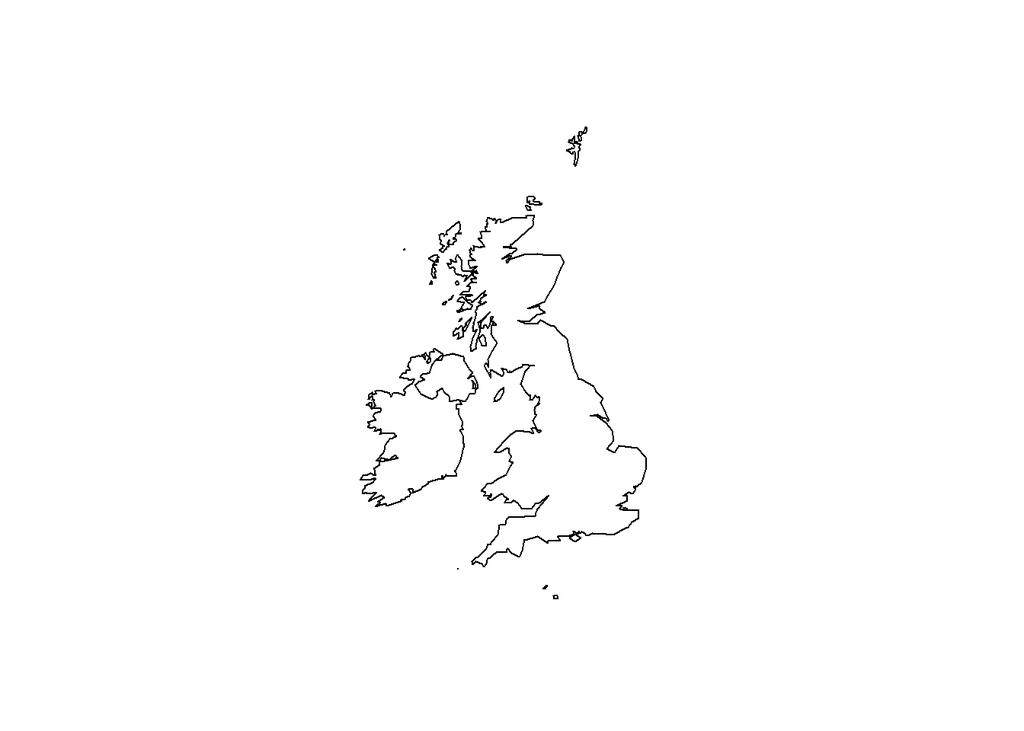

Source : https://www.students.ncl.ac.uk/keith.newman/r/maps-in-r#setUp